# Project Week 12

## Business Understanding

A Kenyan entrepreneur has created an online cryptography course and would want to advertise it on her blog. She currently targets audiences originating from various countries. In the past, she ran ads to advertise a related course on the same blog and collected data in the process. She would now like to employ your services as a Data Science Consultant to help her identify which individuals are most likely to click on her ads.

In order to work on the above problem, you need to do the following:

Define the question, the metric for success, the context, experimental design taken and the appropriateness of the available data to answer the given question. Find and deal with outliers, anomalies, and missing data within the dataset. Perform univariate and bivariate analysis. From your insights provide a conclusion and recommendation.

## Reading our data

```r
## Importing our libraries.

library(readxl)
```

```r
## Importing our dataset

advertising <- read_excel("C:/Users/HP/Downloads/advertising.xlsx")
```

## Checking our data

```r
#Reading our data

##Since we have already imported our dataset, we will preview the first 6 rows of the data.

head(advertising)
```

```
## # A tibble: 6 x 10
##   `Daily Time Spe~   Age `Area Income` `Daily Internet~ `Ad Topic Line` City
##              <dbl> <dbl>         <dbl>            <dbl> <chr>           <chr>
## 1             69.0    35        61834.             256. Cloned 5thgene~ Wrig~
## 2             80.2    31        68442.             194. Monitored nati~ West~
## 3             69.5    26        59786.             236. Organic bottom~ Davi~
## 4             74.2    29        54806.             246. Triple-buffere~ West~
## 5             68.4    35        73890.             226. Robust logisti~ Sout~
## 6             60.0    23        59762.             227. Sharable clien~ Jami~
## # ... with 4 more variables: Male <dbl>, Country <chr>, Timestamp <dttm>,
## #   `Clicked on Ad` <dbl>
```

```r
##Previewing the bottom of our dataset

tail(advertising)
```

```
## # A tibble: 6 x 10
##   `Daily Time Spe~   Age `Area Income` `Daily Internet~ `Ad Topic Line` City
##              <dbl> <dbl>         <dbl>            <dbl> <chr>           <chr>
## 1             43.7    28        63127.             173. Front-line bif~ Nich~
## 2             73.0    30        71385.             209. Fundamental mo~ Duff~
## 3             51.3    45        67782.             134. Grass-roots co~ New ~
## 4             51.6    51        42416.             120. Expanded intan~ Sout~
## 5             55.6    19        41921.             188. Proactive band~ West~
## 6             45.0    26        29876.             178. Virtual 5thgen~ Ronn~
## # ... with 4 more variables: Male <dbl>, Country <chr>, Timestamp <dttm>,
## #   `Clicked on Ad` <dbl>
```

```r
##Determining the number of records in our data

dim(advertising)
```

```
## [1] 1000   10
```

```r
## Previewing the column names in our data

colnames(advertising)
```

```
##  [1] "Daily Time Spent on Site" "Age"
##  [3] "Area Income"              "Daily Internet Usage"
##  [5] "Ad Topic Line"            "City"
##  [7] "Male"                     "Country"
##  [9] "Timestamp"                "Clicked on Ad"
```

```r
##Obtaining a summary of our data

summary(advertising)
```

```
##  Daily Time Spent on Site      Age         Area Income    Daily Internet Usage
##  Min.   :32.60            Min.   :19.00   Min.   :13996   Min.   :104.8
##  1st Qu.:51.36            1st Qu.:29.00   1st Qu.:47032   1st Qu.:138.8
##  Median :68.22            Median :35.00   Median :57012   Median :183.1
##  Mean   :65.00            Mean   :36.01   Mean   :55000   Mean   :180.0
##  3rd Qu.:78.55            3rd Qu.:42.00   3rd Qu.:65471   3rd Qu.:218.8
##  Max.   :91.43            Max.   :61.00   Max.   :79485   Max.   :270.0
##  Ad Topic Line          City                Male         Country
##  Length:1000        Length:1000        Min.   :0.000   Length:1000
##  Class :character   Class :character   1st Qu.:0.000   Class :character
##  Mode  :character   Mode  :character   Median :0.000   Mode  :character
##                                        Mean   :0.481
##                                        3rd Qu.:1.000
##                                        Max.   :1.000
##    Timestamp                   Clicked on Ad
##  Min.   :2016-01-01 02:52:10   Min.   :0.0
##  1st Qu.:2016-02-18 02:55:42   1st Qu.:0.0
##  Median :2016-04-07 17:27:29   Median :0.5
##  Mean   :2016-04-10 10:34:06   Mean   :0.5
##  3rd Qu.:2016-05-31 03:18:14   3rd Qu.:1.0
##  Max.   :2016-07-24 00:22:16   Max.   :1.0
```

## Tidying our data

```r
#Tidying our dataset

## Checking for any duplicated values

Duplicate <- advertising[duplicated(advertising),]

Duplicate
```

```
## # A tibble: 0 x 10
## # ... with 10 variables: `Daily Time Spent on Site` <dbl>, Age <dbl>, `Area
## #   Income` <dbl>, `Daily Internet Usage` <dbl>, `Ad Topic Line` <chr>,
## #   City <chr>, Male <dbl>, Country <chr>, Timestamp <dttm>, `Clicked on
## #   Ad` <dbl>
```

```r
## We have confirmed that our data has no duplicated values.
```

```r
## Checking for any missing values

colSums(is.na(advertising))
```

```
## Daily Time Spent on Site                      Age              Area Income
##                        0                        0                        0
##     Daily Internet Usage            Ad Topic Line                     City
##                        0                        0                        0
##                     Male                  Country                Timestamp
##                        0                        0                        0
##            Clicked on Ad
##                        0
```

```r
## Our data has no missing values, hence ready for analysis
```

```r
## Assigning our numerical columns to their variable names

age <- advertising$Age
area <- advertising$`Area Income`
time <- advertising$`Daily Time Spent on Site`
usage <- advertising$`Daily Internet Usage`
```

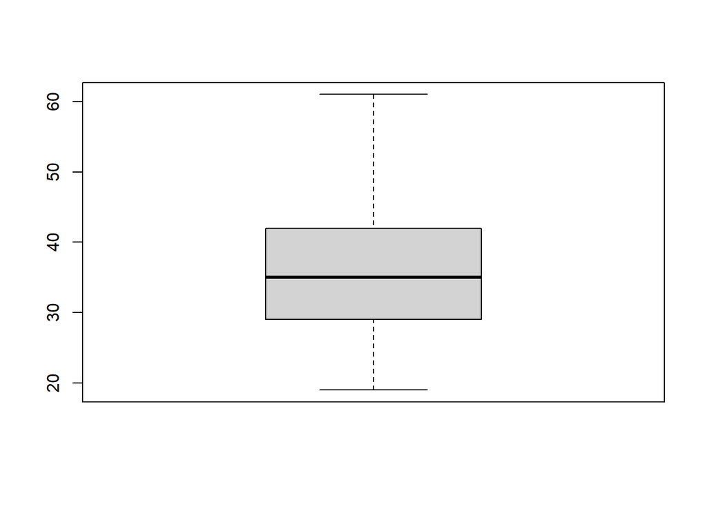

```r
## Plotting boxplots to visualize outliers in our numerical columns

boxplot(age)
```

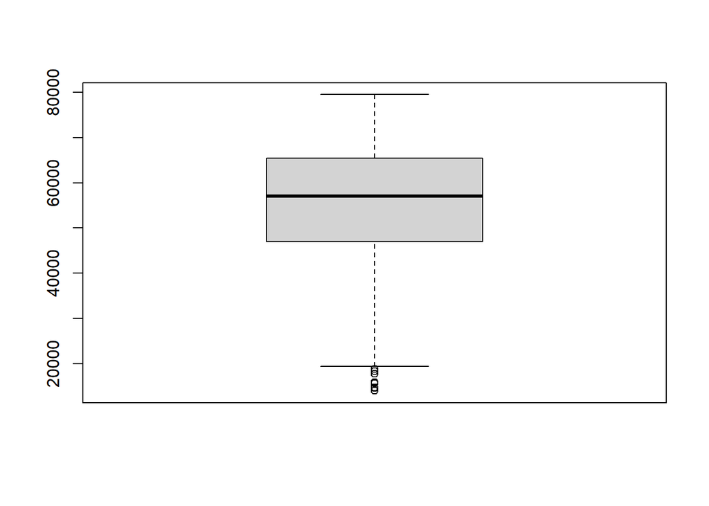

```r
## Visualisation of outliers in the Area income column

boxplot(area)
```

```r
## This column happens to be the only column with outliers
```

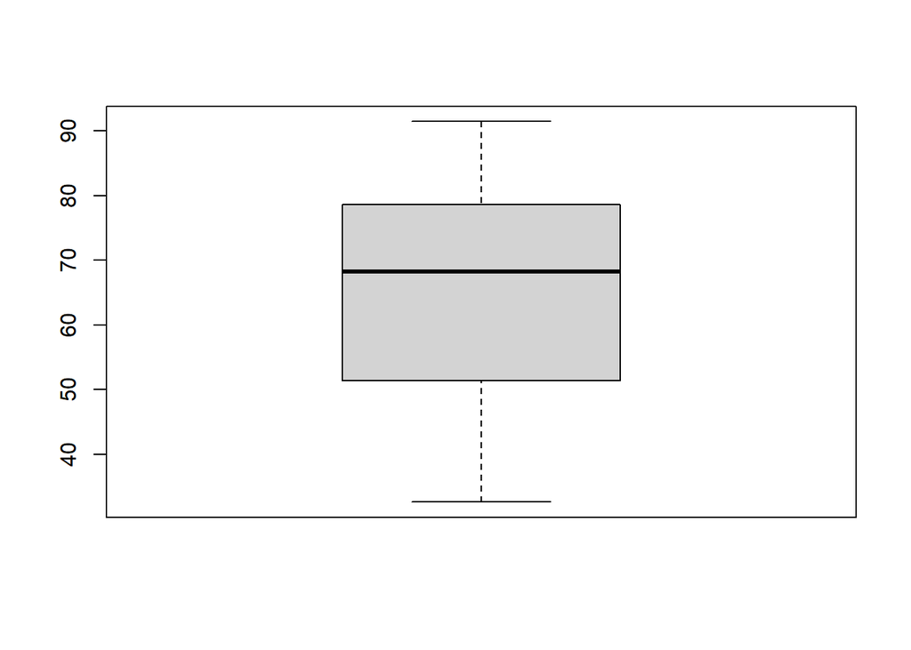

```r
## A boxplot visual of Daily Time Spent on Site

boxplot(time)
```

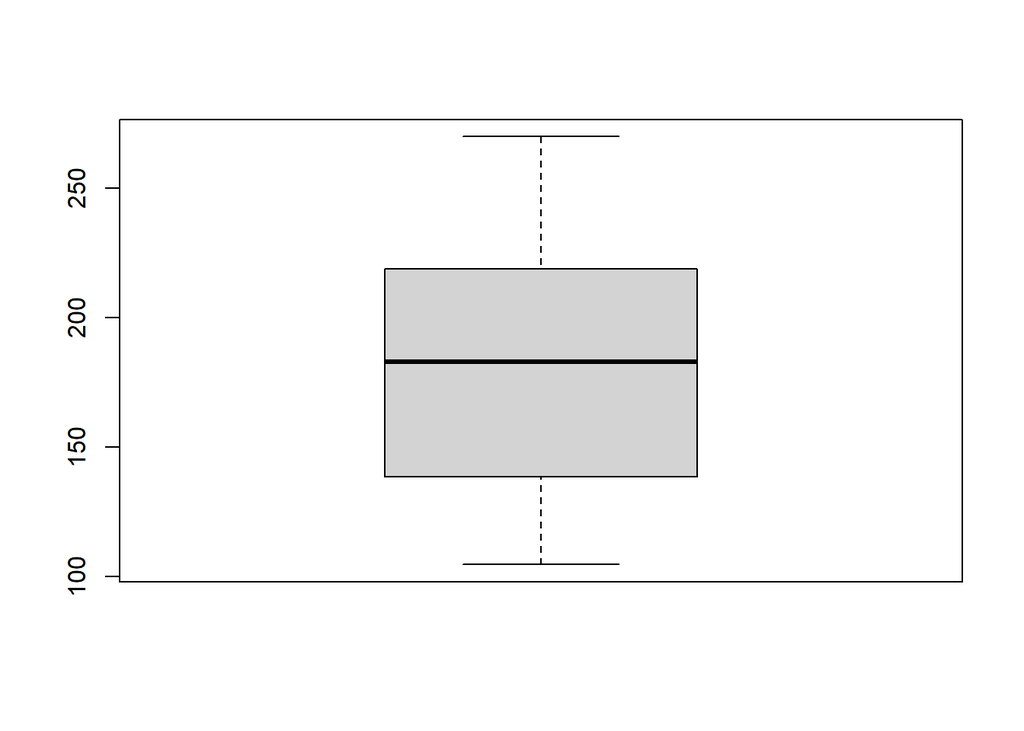

```r
##A visual for Daily Internet Usage

boxplot(usage)
```

```r
## Showing the outliers in our Area Income column

boxplot.stats(area)$out
```

```
## [1] 17709.98 18819.34 15598.29 15879.10 14548.06 13996.50 14775.50 18368.57
```

```r
## All our outliers are income values less than 20,000
```

```r
## Dropping the outliers in our data

data <- subset(advertising,`Area Income` > 19000)

data
```

```
## # A tibble: 992 x 10
##    `Daily Time Spe~   Age `Area Income` `Daily Internet~ `Ad Topic Line` City
##               <dbl> <dbl>         <dbl>            <dbl> <chr>           <chr>
##  1             69.0    35        61834.             256. Cloned 5thgene~ Wrig~
##  2             80.2    31        68442.             194. Monitored nati~ West~
##  3             69.5    26        59786.             236. Organic bottom~ Davi~
##  4             74.2    29        54806.             246. Triple-buffere~ West~
##  5             68.4    35        73890.             226. Robust logisti~ Sout~
##  6             60.0    23        59762.             227. Sharable clien~ Jami~
##  7             88.9    33        53853.             208. Enhanced dedic~ Bran~
##  8             66      48        24593.             132. Reactive local~ Port~
##  9             74.5    30        68862              222. Configurable c~ West~
## 10             69.9    20        55642.             184. Mandatory homo~ Rami~
## # ... with 982 more rows, and 4 more variables: Male <dbl>, Country <chr>,
## #   Timestamp <dttm>, `Clicked on Ad` <dbl>
```

```r
## Dtermining the classes available in our data
class(data)
```

```
## [1] "tbl_df"     "tbl"        "data.frame"
```